# AUS RAIN DATA

round 1 & 2 Clean set of RainToday

```r
data1aus <- ausdata[complete.cases(ausdata$RainToday),]
dataRTRT <- data1aus[complete.cases(data1aus$RainTomorrow),]
```

Plot what results based on country, based on data and RainToday:

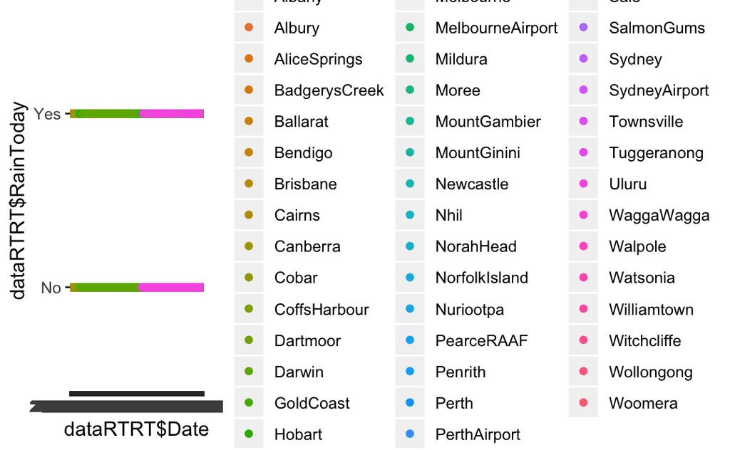

```r
qplot(x = dataRTRT$Date, y = dataRTRT$RainToday, col = dataRTRT$Location)
```

Was a mistake.. BUT there is no presence of N/A’s

Plot what results based on country, based on data and RainTomorrow:

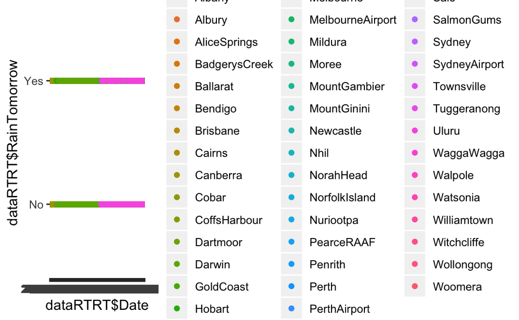

```r
qplot(x = dataRTRT$Date, y = dataRTRT$RainTomorrow, col = dataRTRT$Location)
```

All HOPE lost… CHEAT… we need no NA’s data without Null’s..

```r
dataDD <-  na.omit(dataRTRT)
head(dataDD)
```

|  | Date | Location | MinTemp | MaxTemp | Rainfall | Evaporation | Sunshine | WindGustDir | WindGustSpeed | WindDir9am | WindDir3pm | WindSpeed9am | WindSpeed3pm | Humidity9am | Humidity3pm | Pressure9am | Pressure3pm | Cloud9am | Cloud3pm | Temp9am | Temp3pm | RainToday | RISK_MM | RainTomorrow |
| --- | --- | --- | --- | --- | --- | --- | --- | --- | --- | --- | --- | --- | --- | --- | --- | --- | --- | --- | --- | --- | --- | --- | --- | --- |
| 5940 | 2009-01-01 | Cobar | 17.9 | 35.2 | 0 | 12.0 | 12.3 | SSW | 48 | ENE | SW | 6 | 20 | 20 | 13 | 1006.3 | 1004.4 | 2 | 5 | 26.6 | 33.4 | No | 0 | No |
| 5941 | 2009-01-02 | Cobar | 18.4 | 28.9 | 0 | 14.8 | 13.0 | S | 37 | SSE | SSE | 19 | 19 | 30 | 8 | 1012.9 | 1012.1 | 1 | 1 | 20.3 | 27.0 | No | 0 | No |
| 5943 | 2009-01-04 | Cobar | 19.4 | 37.6 | 0 | 10.8 | 10.6 | NNE | 46 | NNE | NNW | 30 | 15 | 42 | 22 | 1012.3 | 1009.2 | 1 | 6 | 28.7 | 34.9 | No | 0 | No |
| 5944 | 2009-01-05 | Cobar | 21.9 | 38.4 | 0 | 11.4 | 12.2 | WNW | 31 | WNW | WSW | 6 | 6 | 37 | 22 | 1012.7 | 1009.1 | 1 | 5 | 29.1 | 35.6 | No | 0 | No |
| 5945 | 2009-01-06 | Cobar | 24.2 | 41.0 | 0 | 11.2 | 8.4 | WNW | 35 | NW | WNW | 17 | 13 | 19 | 15 | 1010.7 | 1007.4 | 1 | 6 | 33.6 | 37.6 | No | 0 | No |
| 5946 | 2009-01-07 | Cobar | 27.1 | 36.1 | 0 | 13.0 | 0.0 | N | 43 | N | WNW | 7 | 20 | 26 | 19 | 1007.7 | 1007.4 | 8 | 8 | 30.7 | 34.3 | No | 0 | No |

Create train, test data from the data (de Nulled)

```r
set.seed(123)
sample <- sample.split(dataDD,SplitRatio = 0.75)
train <- subset(dataDD, sample==TRUE)
test  <- subset(dataDD, sample==FALSE)
```

Specify variables/columns which I thought would affect the weather.. and create a decision tree based on that.

```r
fit <-  rpart(RainToday ~ Location + MinTemp + MaxTemp +Temp9am+Humidity9am+Pressure9am+Cloud9am+ Evaporation + Sunshine,
              method = "class",
              data = dataDD,
              control =rpart.control(minsplit = 1, depth= 5),
              parms= list(split ="information"))
```

Plot the decision tree..

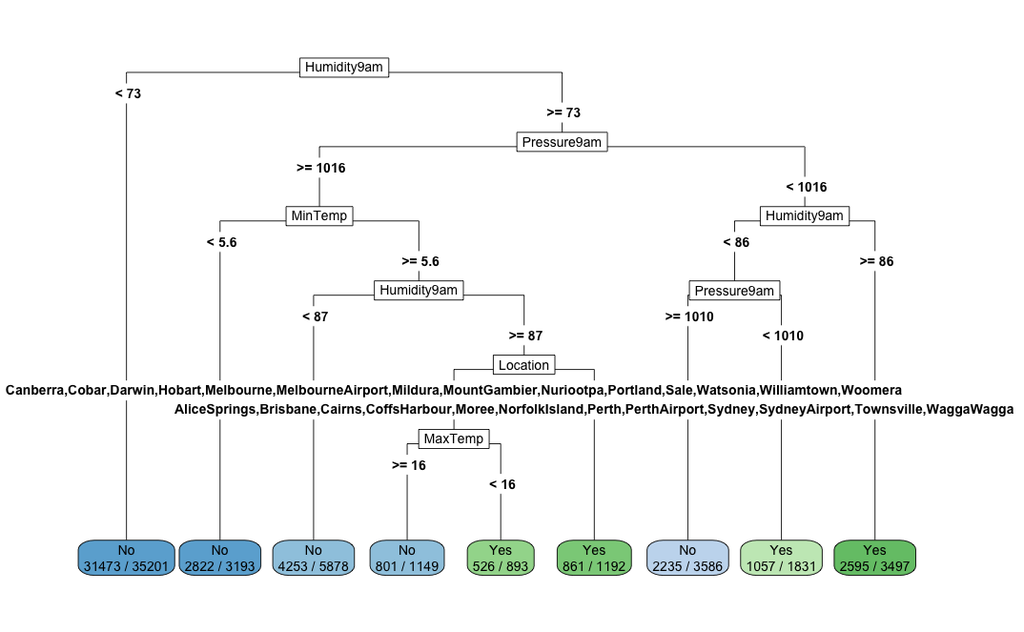

```r
rpart.plot(fit, type=5, extra=2)
```

Perform a prediction

```r
predict(fit, test)
```

```
              No       Yes
5945   0.8940939 0.1059061
5948   0.8940939 0.1059061
5951   0.8940939 0.1059061
5956   0.8940939 0.1059061
5960   0.8940939 0.1059061
5964   0.8940939 0.1059061
5969   0.8940939 0.1059061
5972   0.8940939 0.1059061
5975   0.8940939 0.1059061
5980   0.8940939 0.1059061
5984   0.6232571 0.3767429
5988   0.8940939 0.1059061
5993   0.8940939 0.1059061
5996   0.8940939 0.1059061
```

[output cut: 487 more lines]

Remove RainToday so that i can test.

```r
dataDDT <- dataDD
dataDD$RainToday <- NULL
```

Perform another prediction and produce a matrix:

```r
Predict_dd <-  predict(object=fit,
                        newdata= test,
                        type="class")
confusionMatrix(data=Predict_dd, reference= test$RainToday)
```

```
Confusion Matrix and Statistics

          Reference
Prediction    No   Yes
       No  10448  1821
       Yes   612  1224

               Accuracy : 0.8275
                 95% CI : (0.8212, 0.8337)
    No Information Rate : 0.7841
    P-Value [Acc > NIR] : < 2.2e-16

                  Kappa : 0.4049
 Mcnemar's Test P-Value : < 2.2e-16

            Sensitivity : 0.9447
            Specificity : 0.4020
         Pos Pred Value : 0.8516
         Neg Pred Value : 0.6667
             Prevalence : 0.7841
         Detection Rate : 0.7407
   Detection Prevalence : 0.8698
      Balanced Accuracy : 0.6733

       'Positive' Class : No
```

predictdd

compare id by id by test data and check value.

test$RainTomorrow Predict_dd YES/NO

```r
score <- 0
for (i in 1:nrow(test)){
  if (test$RainTomorrow[i] == Predict_dd[i]) {
    score <- score+1
  }
}
(score / nrow(test))*100
```

```
[1] 80.08508
```

TUNE it..